# Stat 480 - Homework #5

Zahra Khoshmanesh

2/20/2020

## Flying etiquette

1. Download the RMarkdown file with these homework instructions to use as a template for your work. Make sure to replace “Your Name” in the YAML with your name.
2. FiveThirtyEight is a website founded by Statistician and writer Nate Silver to publish results from opinion poll analysis, politics, economics, and sports blogging. One of the featured articles considers [flying etiquette](https://fivethirtyeight.com/features/airplane-etiquette-recline-seat/). This article is based on data collected by FiveThirtyEight and publicly available on github. Use the code below to read in the data from the survey:

```r
fly <- read.csv("https://raw.githubusercontent.com/fivethirtyeight/data/master/flying-etiquette-survey/flying-etiquette.csv")
```

The next couple of lines of code provide a bit of cleanup of the demographic information by reordering the levels of the corresponding factor variables. Run this code in your session.

```r
fly$Age <- factor(fly$Age, levels=c("18-29", "30-44", "45-60", "> 60", ""))
fly$Household.Income <- factor(fly$Household.Income, levels = c("$0 - $24,999","$25,000 - $49,999", "$50,000 - $99,999", "$100,000 - $149,999", "150000", ""))
fly$Education <- factor(fly$Education, levels = c("Less than high school degree", "High school degree", "Some college or Associate degree", "Bachelor degree",  "Graduate degree", ""))
```

3. Some people do not travel often by plane. Provide a breakdown of travel frequency (use variable `How.often.do.you.travel.by.plane.`). Reorder the levels in the variable by travel frequency from least frequent travel to most frequent. Draw a barchart of travel frequency and comment on it.

```r
#factor levels befor reordering
levels(fly$How.often.do.you.travel.by.plane.)
```

```
## [1] "A few times per month" "A few times per week"  "Every day"
## [4] "Never"                 "Once a month or less"  "Once a year or less"
```

```r
#check if we have empty value for this variable
any(fly$How.often.do.you.travel.by.plane.==" ")
```

```
## [1] FALSE
```

```r
#reorder
fly$How.often.do.you.travel.by.plane. <- factor(fly$How.often.do.you.travel.by.plane.,
                                                levels=c("Never","Once a year or less","Once a month or less" ,"A few times per month",
                                                         "A few times per week","Every day"))
#factor levels after reordering
levels(fly$How.often.do.you.travel.by.plane.)
```

```
## [1] "Never"                 "Once a year or less"   "Once a month or less"
## [4] "A few times per month" "A few times per week"  "Every day"
```

If question is to order levels based on the frequency of levels in the data :

most frequent level ordered as follows :

“Once a year or less” “Once a month or less” “Never” “A few times per month” “A few times per week” “Every day”

```r
# if question ask to reorder levels based on the frequency of levels in data

fly$How.often.do.you.travel.by.plane. <- factor(fly$How.often.do.you.travel.by.plane.,
                                                levels=c("Once a year or less",
                                                         "Once a month or less",
                                                         "Never",
                                                         "A few times per month",
                                                         "A few times per week",
                                                         "Every day"))
```

Draw a barchart of travel frequency and comment on it

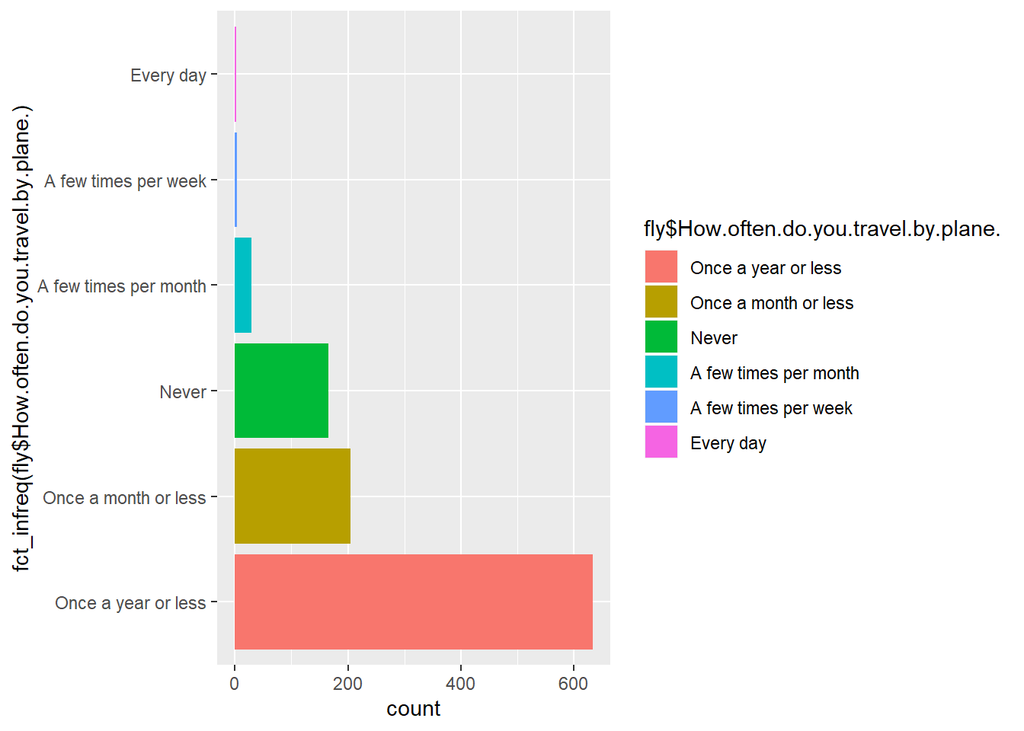

```r
library(forcats)

ggplot(data=fly, aes(x=fct_infreq(fly$How.often.do.you.travel.by.plane.),fill=fly$How.often.do.you.travel.by.plane.)) +
  geom_bar()+
  coord_flip()
```

**Chart Interpretation**

based on the result of abov egraph: most of people travel once a year or less following with once a month or less since these two categories are the highest frequent categories.

4. In the demographic variables (`Education`, `Age`, and `Houshold.Income`), replace all occurrences of the empty string "" by a missing value `NA`. How many responses do not have any missing values? (Hint: the function `is.na` might come in handy)

```r
#let us check the na value in education,age and household.income
str(fly$Education)
```

```
##  Factor w/ 6 levels "Less than high school degree",..: 6 5 4 4 4 5 3 4 6 4 ...
```

```r
levels(fly$Education)
```

```
## [1] "Less than high school degree"     "High school degree"
## [3] "Some college or Associate degree" "Bachelor degree"
## [5] "Graduate degree"                  ""
```

```r
levels(fly$Education)[6] <- NA
levels(fly$Education)
```

```
## [1] "Less than high school degree"     "High school degree"
## [3] "Some college or Associate degree" "Bachelor degree"
## [5] "Graduate degree"
```

```r
str(fly$Age)
```

```
##  Factor w/ 5 levels "18-29","30-44",..: 5 2 2 2 2 2 2 2 5 2 ...
```

```r
levels(fly$Age)
```

```
## [1] "18-29" "30-44" "45-60" "> 60"  ""
```

```r
levels(fly$Age)[5] <- NA
levels(fly$Age)
```

```
## [1] "18-29" "30-44" "45-60" "> 60"
```

```r
str(fly$Household.Income)
```

```
##  Factor w/ 6 levels "$0 - $24,999",..: 6 6 4 1 3 2 5 1 6 1 ...
```

```r
levels(fly$Household.Income)
```

```
## [1] "$0 - $24,999"        "$25,000 - $49,999"   "$50,000 - $99,999"
## [4] "$100,000 - $149,999" "150000"              ""
```

```r
levels(fly$Household.Income)[6] <- NA
levels(fly$Household.Income)
```

```
## [1] "$0 - $24,999"        "$25,000 - $49,999"   "$50,000 - $99,999"
## [4] "$100,000 - $149,999" "150000"
```

How many responses do not have any missing values? (Hint: the function `is.na` might come in handy)

let us first calculate how many responds has the missing value in one of these three variables: age, education, household.income

```r
sum((is.na(fly$Age) | is.na(fly$Education) | is.na(fly$Household.Income)))
```

```
## [1] 216
```

216 rows has missing value in at least one of these three variables.

now we use logical operator ! and count the number of rows that do not have missing value.

```r
sum(!(is.na(fly$Age) | is.na(fly$Education) | is.na(fly$Household.Income)))
```

```
## [1] 824
```

and 824 rows do not have missing value in these three variables.

5. Run the command below and interpret the output. What potential purpose can you see for the chart?

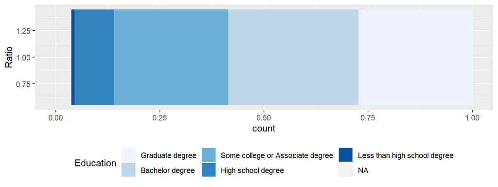

```r
library(ggplot2)
fly$Education = with(fly, factor(Education, levels = rev(levels(Education))))

ggplot(data = fly, aes(x = 1)) +
  geom_bar(aes(fill=Education), position="fill") +
  coord_flip() +
  theme(legend.position="bottom") +
  scale_fill_brewer() +
  xlab("Ratio")
```

```r
#calculate the ratio to confirm the result of interpretation
fly %>% select(Education) %>% group_by(Education) %>% summarise(ratio=n()/nrow(fly))
```

```
## # A tibble: 6 x 2
##   Education                          ratio
##   <fct>                              <dbl>
## 1 Graduate degree                  0.273
## 2 Bachelor degree                  0.312
## 3 Some college or Associate degree 0.275
## 4 High school degree               0.0942
## 5 Less than high school degree     0.00769
## 6 <NA>                             0.0375
```

6. Rename the variable `In.general..is.itrude.to.bring.a.baby.on.a.plane.` to `baby.on.plane.`. How many levels does the variable `baby.on.plane` have, and what are these levels? Rename the level labeled "" to “Not answered”. Reorder the levels of `baby.on.plane` from least rude to most rude. Put the level “Not answered” last. Draw a barchart of variable `baby.on.plane`. Interpret the result.

```r
names(fly) #check the index of In.general..is.itrude.to.bring.a.baby.on.a.plane.
```

```
##  [1] "RespondentID"
##  [2] "How.often.do.you.travel.by.plane."
##  [3] "Do.you.ever.recline.your.seat.when.you.fly."
##  [4] "How.tall.are.you."
##  [5] "Do.you.have.any.children.under.18."
##  [6] "In.a.row.of.three.seats..who.should.get.to.use.the.two.arm.rests."
##  [7] "In.a.row.of.two.seats..who.should.get.to.use.the.middle.arm.rest."
##  [8] "Who.should.have.control.over.the.window.shade."
##  [9] "Is.itrude.to.move.to.an.unsold.seat.on.a.plane."
## [10] "Generally.speaking..is.it.rude.to.say.more.than.a.few.words.tothe.stranger.sitting.next.to.you.on.a.plane."
## [11] "On.a.6.hour.flight.from.NYC.to.LA..how.many.times.is.it.acceptable.to.get.up.if.you.re.not.in.an.aisle.seat."
## [12] "Under.normal.circumstances..does.a.person.who.reclines.their.seat.during.a.flight.have.any.obligation.to.the.person.sitting.behind.them."
## [13] "Is.itrude.to.recline.your.seat.on.a.plane."
## [14] "Given.the.opportunity..would.you.eliminate.the.possibility.of.reclining.seats.on.planes.entirely."
## [15] "Is.it.rude.to.ask.someone.to.switch.seats.with.you.in.order.to.be.closer.to.friends."
## [16] "Is.itrude.to.ask.someone.to.switch.seats.with.you.in.order.to.be.closer.to.family."
## [17] "Is.it.rude.to.wake.a.passenger.up.if.you.are.trying.to.go.to.the.bathroom."
## [18] "Is.itrude.to.wake.a.passenger.up.if.you.are.trying.to.walk.around."
## [19] "In.general..is.itrude.to.bring.a.baby.on.a.plane."
## [20] "In.general..is.it.rude.to.knowingly.bring.unruly.children.on.a.plane."
## [21] "Have.you.ever.used.personal.electronics.during.take.off.or.landing.in.violation.of.a.flight.attendant.s.direction."
## [22] "Have.you.ever.smoked.a.cigarette.in.an.airplane.bathroom.when.it.was.against.the.rules."
## [23] "Gender"
## [24] "Age"
## [25] "Household.Income"
## [26] "Education"
## [27] "Location..Census.Region."
```

```r
names(fly)[19] <- "baby.on.plane."
length(levels(fly$baby.on.plane.))
```

```
## [1] 4
```

```r
levels(fly$baby.on.plane.)
```

```
## [1] ""                    "No, not at all rude" "Yes, somewhat rude"
## [4] "Yes, very rude"
```

it has 4 levels : ""  
“No, not at all rude” “Yes, somewhat rude” “Yes, very rude”

```r
levels(fly$baby.on.plane.)[1] <- "Not answered"
fly$baby.on.plane. <- factor(fly$baby.on.plane.,levels=c("No, not at all rude","Yes, somewhat rude" ,"Yes, very rude","Not answered"))
levels(fly$baby.on.plane.)
```

```
## [1] "No, not at all rude" "Yes, somewhat rude"  "Yes, very rude"
## [4] "Not answered"
```

Draw a barchart of variable `baby.on.plane`. Interpret the result.

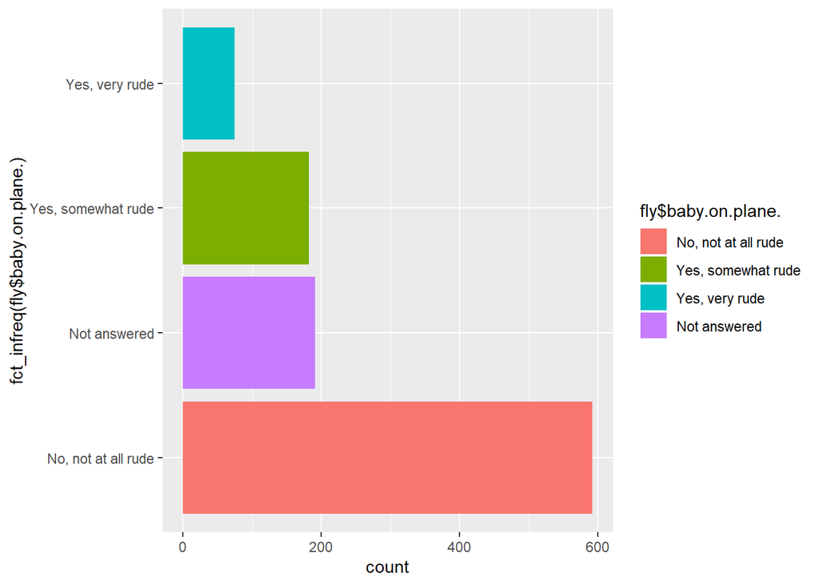

```r
ggplot(data=fly, aes(x=fct_infreq(fly$baby.on.plane.),fill=fly$baby.on.plane.)) +
  geom_bar()+
  coord_flip()
```

**Interpret**

most of people beleive baby was not rude during the flight. only a few people answered very rude.

7. Investigate the relationship between gender and the variables `Do.you.have.any.children.under.18.` and `baby.on.plane`. How is the attitude towards babies on planes shaped by gender and having children under 18? Find a plot that summarises your findings (use `ggplot2`).

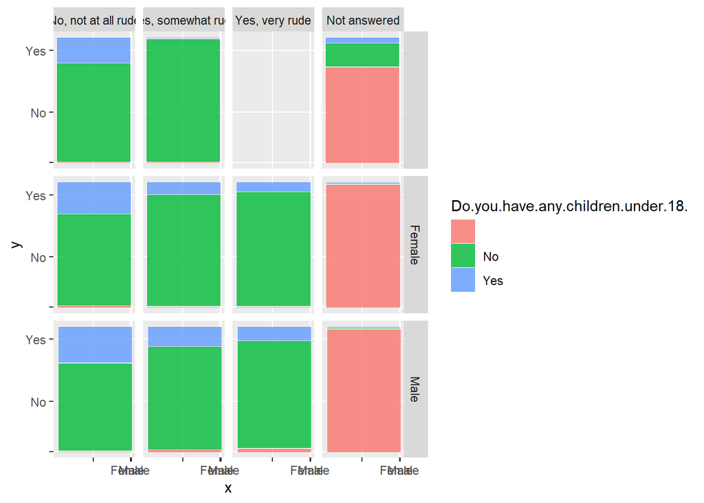

```r
library(ggmosaic)
ggplot(data = fly)  +
  geom_mosaic(aes(x = product(Gender), fill=Do.you.have.any.children.under.18., weight=1)) +
  facet_grid(Gender~baby.on.plane.)
```

**Interpretation**

the majority of both females and males that answered baby were rude or somewhat rude on the plane mostly do not have childeren under 18.